# UDF vs plain R - bfast

peterjames.zellner@eurac.edu

17/03/2022

## Libraries

```r
library("stars")
library("sf")
library("bfast")
library("mapview")
library("dplyr")
library("ggplot2")
library("units")
library("lubridate")
library("openeo")
```

## Create Process Graph up to UDF

Here we’re creating the process graph up to the point where the UDF would run.

```r
host = "https://openeo.cloud"
con = connect(host, provider = "egi")

spatial_extent = list("west" = 11.564,
                      "east" = 11.577,
                      "south" = 46.454,
                      "north" = 46.461) # ~ 35*26px = 910 px

temporal_extent = list("2016-01-01", "2020-01-01") # 5 yrs, 6 daily = 365*5/6 = 300 ts
collection = "SENTINEL2_L2A"
bands = c("B04", "B08", "CLD")

p = processes()
s2 = p$load_collection(bands = bands,
                       id = collection,
                       spatial_extent = spatial_extent,
                       temporal_extent = temporal_extent)
s2_cld = p$filter_bands(bands = list("CLD"),
                        data = s2, wavelengths = list())
s2_bnd = p$filter_bands(bands = list("B04", "B08"),
                        data = s2, wavelengths = list())
s2_ndvi = p$ndvi(data = s2_bnd, nir = "B08", red = "B04")
s2_masked = p$mask(data = s2_ndvi, mask = s2_cld)
# s2_linint = p$apply_dimension(data = s2_masked,
#                               dimension = "t",
#                               process = function(x, context){
#                                 p$array_interpolate_linear(x)})
s2_result = p$save_result(data = s2_masked, format = "NETCDF")

# View the process
udp = as(s2_result,"Process")
process_viewer(udp)
```

In case we want to run this

```r
# Batch
format = "NETCDF"
title = "r4openeo_uc2_ndvi_bfast_mskd3"
out_dir = "/home/pzellner@eurac.edu/"
job = create_job(graph=s2_result, title = title)
start_job(job = job)
describe_job(job = job)
list_results(job = job)
dwnld = download_results(job = job, folder = paste0(out_dir, title))
```

## Get NDVI Data from openEO platform

This is a NDVI time series processed on openEO cloud using this process graph

```r
pth_ndvi = "~/git_projects/openeo-udf-python-to-r/r4openeo_uc2_ndvi_mskd_small.nc"
ndvi = stars::read_ncdf(pth_ndvi)
st_crs(ndvi) = st_crs(32632)
```

## bfast spatial

This is the function used in py2. It is trimmed to xarray data structure, so not working in plain R.

```r
source(file = "~/git_projects/openeo-udf-python-to-r/udfs/reduce_bfast.R")
```

This is the function we based the udf upon.

```r
spatial_bfm = function(pixels, dates, start_monitor = 2018, level = c(0.001, 0.001),
                       val = "breakpoint") {
  # error handling
  stopifnot(length(pixels) == length(dates))
  stopifnot(val %in% c("breakpoint", "magnitude"))

  # create ts object for bfast
  lsts = bfastts(pixels, dates, type = c("irregular"))

  # make sure there are enough observations
  if (sum(!is.na(lsts)) < 100){
    return(NA)
  }

  # run bfast and return the selected value into the raster
  res = bfastmonitor(lsts,
                     start_monitor,
                     formula = response~harmon,
                     order = 1,
                     history = "all",
                     level = level,
                     verbose = F)[[val]]
  if(is.na(res)){
    return(0)
  }
  return(res)
}
```

## Apply bfast

Run the function on the NDVI time series in plain R.

```r
level = c(0.001, 0.001)
start_monitor = 2018
dates = st_get_dimension_values(ndvi, "t")

a = Sys.time()
bfast_brks = st_apply(X = ndvi, MARGIN = c("x", "y"), function(x){
  spatial_bfm(pixels = x,
              dates = dates,
              start_monitor = start_monitor,
              level = level, val = "breakpoint")
})
b = Sys.time()
duration = b-a

write_stars(obj = bfast_brks, dsn = "~/git_projects/openeo-udf-python-to-r/result_bfast_r_small.nc")
```

## Compare plain R and UDF results

### Runtime

The runtime of the UDF is for

- 50x50x400: 40 sec
- 256x256x400: 30 min

The runtime of the plain R for dims(x, y, t) 43, 50, 403 is 12.00309 secs

### Spatial Coherence

Get the UDF result

```r
pth_udf_result = "~/git_projects/openeo-udf-python-to-r/result_bfast_udf_small.nc"
bfast_brks_udf = stars::read_stars(pth_udf_result)
st_crs(bfast_brks_udf) = st_crs(32632)
bfast_brks_udf[[1]][bfast_brks_udf[[1]] < 2018] = NA
bfast_brks_udf[[1]][bfast_brks_udf[[1]] > 2020] = NA
```

Get the plain R result

```r
pth_r_result = "~/git_projects/openeo-udf-python-to-r/result_bfast_r_small.nc"
bfast_brks_r = stars::read_stars(pth_r_result)
bfast_brks_r[[1]][bfast_brks_r[[1]] < 2018] = NA
bfast_brks_r[[1]][bfast_brks_r[[1]] > 2020] = NA
```

Get the results from the project ECO4Alps. There we were using the Harmonized Landsat Sentinel Collection at 30m resolution.

```r
#pth_eco4alps = "/mnt/CEPH_PROJECTS/ECO4Alps/Forest_Disturbances/03_results/bfast/magn_2016_2020_start_2018_level_0.001.tif"
#bfast_brks_eco = stars::read_stars(pth_eco4alps)
#bfast_brks_eco[[1]][bfast_brks_eco[[1]] > -0.2] = NA
pth_eco4alps = "/mnt/CEPH_PROJECTS/ECO4Alps/Forest_Disturbances/03_results/bfast/brks_2016_2020_start_2018_level_0.001.tif"
bfast_brks_eco = stars::read_stars(pth_eco4alps)
bfast_brks_eco[[1]][bfast_brks_eco[[1]] < 2018] = NA
bfast_brks_eco[[1]][bfast_brks_eco[[1]] > 2020] = NA
bfast_brks_eco = st_warp(src = bfast_brks_eco, dest = bfast_brks_udf)
```

Plain R and UDF results are identical

```r
summary(round(c(bfast_brks_r[[1]] - bfast_brks_udf[[1]]), 3)) # to the 3rd decimal
```

```
##    Min. 1st Qu.  Median    Mean 3rd Qu.    Max.    NA's
##       0       0       0       0       0       0    1397
```

Plot the results

[interactive chart not shown]

### Temporal Trajectory

Select a point interactively.

```r
#pnt = mapedit::drawFeatures(map = mv_comp) %>% st_transform(st_crs(ndvi))
pnt = st_as_sf(data.frame(x = 697653.4, y = 5148280), coords = c("x", "y"), crs = st_crs(32632))
```

Extract the ndvi time series at the point.

```r
ndvi_ts = ndvi[pnt] %>% pull() %>% c()
ndvi_ts = data.frame(ndvi = ndvi_ts,
                     ndvi_int = zoo::na.approx(ndvi_ts),
                     dates = st_get_dimension_values(ndvi, "t"))
```

Extract the breakpoints from the bfast results.

```r
brk_r = bfast_brks_r[pnt] %>% pull() %>% c() %>% date_decimal()
brk_udf = bfast_brks_udf[pnt] %>% pull() %>% c() %>% date_decimal()
brk_eco = bfast_brks_eco[pnt] %>% pull() %>% c() %>% date_decimal()
```

Plot the ndvi time series including the detected breaks.

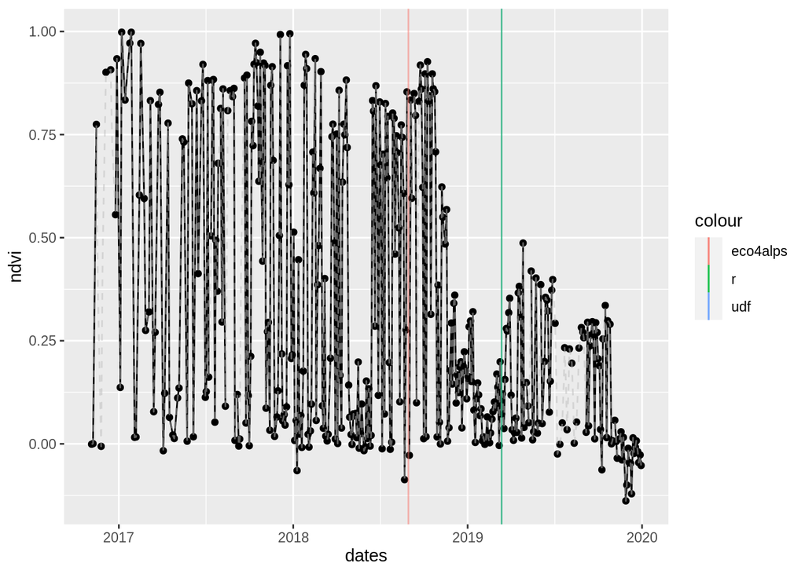